# Covidclinicaltrialanalysis

## Introduction

This analysis focuses on the number of COVID-19 clinical trials that have been registered on https://clinicaltrials.gov/. In order to effectively evaluate the data, it is useful to be familiar with what the ClinicalTrials.gov is and some common clinical trial terminology.

What is ClinicalTrials.gov?

It is a database developed by U.S. National Library of Medicine, hosting information of private and public funded clinical trials.

`Clinical Trial Terminology from the clinicaltrials.gov`

| Term | Definition |
| --- | --- |
| Clinical trial | A research study that involves human participants to evaluate a medical treatment or procedure. |
| Placebo | A harmless substance that looks and tastes like a medication, but does not contain any active ingredients. |
| Double-blind | A type of study design in which neither the participants nor the researchers know which participants are receiving the treatment or the placebo. |
| Phase 2 | A phase of clinical research where preliminary data on whether a drug works in people who have a certain condiction/disease.In this phase, the participants receiving the intervention are compared to t… |
| Phase 3 | A phase where the drug's safety is studied in different populations and different dosages and the drug in combination with other drugs. The number of participants in Phase 3 is larger than Phase 2. |
| Phase 4 | This phase of research occurs after FDA approval on a drug.They include postmarket requirement and commitment studies that are required of or agreed to by the study sponsor.These trials gather additio… |

** Please note that the source of the datasets is Kaggle- https://www.kaggle.com/code/parulpandey/eda-on-covid-19-clinical-trials/data.

`Analysis questions`:

- How many clinical trials were conducted in each phase (2-4) where the condition was related to COVID?
- What phase completed the most covid clinical trials?
- Who are the top three sponsors for clinical trials on COVID related conditions?

Per CDC, the COVID-19 outbreak started in USA on January 18, 2019. And the first clinical trial conducted for COVID-19 was on March 17, 2020 at The University of Minnesota.

Source- https://www.cdc.gov/museum/timeline/covid19.html#:~:text=CDC%20reports%20the%20first%20laboratory,respond%20to%20the%20emerging%20outbreak.

#### Importing Necessary Libaries

```python
!pip install ipython-sql
```

```python
import pandas as pd
import numpy as np
import seaborn as sb
import matplotlib.pyplot as plt
%matplotlib inline
```

#### Reading in the data with Pandas

```python
# Reading in the data
cct = pd.read_csv('COVID clinical trials.csv')
```

```python
cct.head()
```

|  | Rank | NCT Number | Title | Acronym | Status | Study Results | Conditions | Interventions | Outcome Measures | Sponsor/Collaborators | ... | Other IDs | Start Date | Primary Completion Date | Completion Date | First Posted | Results First Posted | Last Update Posted | Locations | Study Documents | URL |
| --- | --- | --- | --- | --- | --- | --- | --- | --- | --- | --- | --- | --- | --- | --- | --- | --- | --- | --- | --- | --- | --- |
| 0 | 1 | NCT04785898 | Diagnostic Performance of the ID Now™ COVID-19... | COVID-IDNow | Active, not recruiting | No Results Available | Covid19 | Diagnostic Test: ID Now™ COVID-19 Screening Test | Evaluate the diagnostic performance of the ID ... | Groupe Hospitalier Paris Saint Joseph | ... | COVID-IDNow | November 9, 2020 | December 22, 2020 | April 30, 2021 | March 8, 2021 | NaN | March 8, 2021 | Groupe Hospitalier Paris Saint-Joseph, Paris, ... | NaN | https://ClinicalTrials.gov/show/NCT04785898 |
| 1 | 2 | NCT04595136 | Study to Evaluate the Efficacy of COVID19-0001... | COVID-19 | Not yet recruiting | No Results Available | SARS-CoV-2 Infection | Drug: Drug COVID19-0001-USR\|Drug: normal saline | Change on viral load results from baseline aft... | United Medical Specialties | ... | COVID19-0001-USR | November 2, 2020 | December 15, 2020 | January 29, 2021 | October 20, 2020 | NaN | October 20, 2020 | Cimedical, Barranquilla, Atlantico, Colombia | NaN | https://ClinicalTrials.gov/show/NCT04595136 |
| 2 | 3 | NCT04395482 | Lung CT Scan Analysis of SARS-CoV2 Induced Lun... | TAC-COVID19 | Recruiting | No Results Available | covid19 | Other: Lung CT scan analysis in COVID-19 patients | A qualitative analysis of parenchymal lung dam... | University of Milano Bicocca | ... | TAC-COVID19 | May 7, 2020 | June 15, 2021 | June 15, 2021 | May 20, 2020 | NaN | November 9, 2020 | Ospedale Papa Giovanni XXIII, Bergamo, Italy\|P... | NaN | https://ClinicalTrials.gov/show/NCT04395482 |
| 3 | 4 | NCT04416061 | The Role of a Private Hospital in Hong Kong Am... | COVID-19 | Active, not recruiting | No Results Available | COVID | Diagnostic Test: COVID 19 Diagnostic Test | Proportion of asymptomatic subjects\|Proportion... | Hong Kong Sanatorium & Hospital | ... | RC-2020-08 | May 25, 2020 | July 31, 2020 | August 31, 2020 | June 4, 2020 | NaN | June 4, 2020 | Hong Kong Sanatorium & Hospital, Hong Kong, Ho... | NaN | https://ClinicalTrials.gov/show/NCT04416061 |
| 4 | 5 | NCT04395924 | Maternal-foetal Transmission of SARS-Cov-2 | TMF-COVID-19 | Recruiting | No Results Available | Maternal Fetal Infection Transmission\|COVID-19... | Diagnostic Test: Diagnosis of SARS-Cov2 by RT-... | COVID-19 by positive PCR in cord blood and / o... | Centre Hospitalier Régional d'Orléans\|Centre d... | ... | CHRO-2020-10 | May 5, 2020 | May 2021 | May 2021 | May 20, 2020 | NaN | June 4, 2020 | CHR Orléans, Orléans, France | NaN | https://ClinicalTrials.gov/show/NCT04395924 |

5 rows × 27 columns

#### Assessment of data quality issues

```python
cct.info()
```

```
<class 'pandas.core.frame.DataFrame'>
RangeIndex: 5783 entries, 0 to 5782
Data columns (total 27 columns):
 #   Column                   Non-Null Count  Dtype
---  ------                   --------------  -----
 0   Rank                     5783 non-null   int64
 1   NCT Number               5783 non-null   object
 2   Title                    5783 non-null   object
 3   Acronym                  2480 non-null   object
 4   Status                   5783 non-null   object
 5   Study Results            5783 non-null   object
 6   Conditions               5783 non-null   object
 7   Interventions            4897 non-null   object
 8   Outcome Measures         5748 non-null   object
 9   Sponsor/Collaborators    5783 non-null   object
```

[output cut: 19 more lines]

```python
cct.shape
```

```
(5783, 27)
```

```python
# columns with null values
cct_null = cct.columns[cct.isnull().any()]
cct_null
```

```
Index(['Acronym', 'Interventions', 'Outcome Measures', 'Gender', 'Phases',
       'Enrollment', 'Study Designs', 'Other IDs', 'Start Date',
       'Primary Completion Date', 'Completion Date', 'Results First Posted',
       'Locations', 'Study Documents'],
      dtype='object')
```

```python
#number of columns with null values
len(cct_null)
```

```
14
```

```python
cct.info()
```

```
<class 'pandas.core.frame.DataFrame'>
RangeIndex: 5783 entries, 0 to 5782
Data columns (total 27 columns):
 #   Column                   Non-Null Count  Dtype
---  ------                   --------------  -----
 0   Rank                     5783 non-null   int64
 1   NCT Number               5783 non-null   object
 2   Title                    5783 non-null   object
 3   Acronym                  2480 non-null   object
 4   Status                   5783 non-null   object
 5   Study Results            5783 non-null   object
 6   Conditions               5783 non-null   object
 7   Interventions            4897 non-null   object
 8   Outcome Measures         5748 non-null   object
 9   Sponsor/Collaborators    5783 non-null   object
```

[output cut: 19 more lines]

```python
# Duplicated values in the cct dataframe if any
cct.duplicated().sum()
```

```
0
```

```python
# Visual Assessment
pd.set_option('display.max_columns', None)
pd.set_option('display.max_colwidth', None)
cct.sample(20)
```

|  | Rank | NCT Number | Title | Acronym | Status | Study Results | Conditions | Interventions | Outcome Measures | Sponsor/Collaborators | Gender | Age | Phases | Enrollment | Funded Bys | Study Type | Study Designs | Other IDs | Start Date | Primary Completion Date | Completion Date | First Posted | Results First Posted | Last Update Posted | Locations | Study Documents | URL |
| --- | --- | --- | --- | --- | --- | --- | --- | --- | --- | --- | --- | --- | --- | --- | --- | --- | --- | --- | --- | --- | --- | --- | --- | --- | --- | --- | --- |
| 1069 | 1070 | NCT04438837 | Hydroxychloroquine Post-Exposure Prophylaxis for Coronavirus Disease (COVID-19) Among Health-Care Workers | NaN | Not yet recruiting | No Results Available | Coronavirus Disease 2019 (COVID-19)\|Post-Exposure Prophylaxis | Drug: Hydroxychloroquine | Clinical COVID-19\|Confirmed COVID-19\|Time to virological recovery\|Time to symptoms onset\|Development of pneumonia\|Development of severe disease\|Need for hospitalization or ICU\|Adverse events\|M… | Rambam Health Care Campus | All | 18 Years and older (Adult, Older Adult) | Not Applicable | 582.0 | Other | Interventional | Allocation: Randomized\|Intervention Model: Parallel Assignment\|Masking: None (Open Label)\|Primary Purpose: Prevention | 0193-20-RMB CTIL | July 2020 | June 2022 | June 2022 | June 19, 2020 | NaN | July 23, 2020 | Rambam Health Care Campus, Haifa, Israel | NaN | https://ClinicalTrials.gov/show/NCT04438837 |
| 139 | 140 | NCT04333862 | Assessment of Covid-19 Infection Rates in Healthcare Workers Using a Desynchronization Strategy | Covid-19 | Recruiting | No Results Available | SARS-CoV-2 | NaN | Fraction of healthcare workers infected with SARS-CoV-2\|Fraction of healthcare workers with COVID-19\|Number of patients infected in the hospital\|Development of SARS-CoV2 specific antibody repertoir… | University Hospital Inselspital, Berne | All | 18 Years and older (Adult, Older Adult) | NaN | 500.0 | Other | Observational | Observational Model: Cohort\|Time Perspective: Prospective | 2020-00563 | March 19, 2020 | January 31, 2022 | January 31, 2022 | April 3, 2020 | NaN | September 30, 2020 | Guido Beldi, Bern, Switzerland | NaN | https://ClinicalTrials.gov/show/NCT04333862 |
| 1277 | 1278 | NCT04715360 | Management of Cytokine Storms in Severe COVID-19 Patients With Autologous Activated Platelet-rich Plasma Therapy | NaN | Recruiting | No Results Available | Covid19\|Sars-CoV-2 Infection\|ARDS, Human\|Severe covid19 | Combination Product: autologous activated platelet-rich plasma\|Drug: Avigan | Effect of aaPRP on pro-inflammatory cytokines plasma level (IL-6, IL-1B, TNFa, IFN gamma, MCP-1) before and after intervention compared to control.\|to evaluate the change of Effect of aaPRP on anti-i… | Hayandra Peduli Foundation\|Koja Regional Public Hospital | All | 18 Years to 65 Years (Adult, Older Adult) | Phase 1\|Phase 2 | 30.0 | Other | Interventional | Allocation: Randomized\|Intervention Model: Parallel Assignment\|Masking: Single (Outcomes Assessor)\|Primary Purpose: Treatment | 20-12-1526 | December 29, 2020 | November 29, 2021 | December 27, 2021 | January 20, 2021 | NaN | January 20, 2021 | Koja Regional Public Hospital, Jakarta, DKI Jakarta, Indonesia | NaN | https://ClinicalTrials.gov/show/NCT04715360 |
| 3587 | 3588 | NCT04359992 | Study of Hemostasis in Case of Severe COVID-19 | THROMBOVID | Not yet recruiting | No Results Available | COVID-19 Infection | Other: Extra blood sample | Platelet activation intensity with the occurrence of clinical thrombotic complications | University Hospital, Strasbourg, France | All | 18 Years and older (Adult, Older Adult) | NaN | 50.0 | Other | Observational | Observational Model: Cohort\|Time Perspective: Prospective | 7774 | April 17, 2020 | April 17, 2021 | May 1, 2021 | April 24, 2020 | NaN | April 24, 2020 | NaN | NaN | https://ClinicalTrials.gov/show/NCT04359992 |
| 1741 | 1742 | NCT04623255 | Randomised Study of Plasma Exchange in Severe COVID-19 | COVIPLEX | Recruiting | No Results Available | COVID19 | Drug: OCTAPLAS | Change in Inflammatory Marker-CRP\|Change in Inflammatory Marker-D Dimer\|Change in Inflammatory Marker-LDH\|Rates of mechanical ventilation\|Rates of clinical thrombotic events\|Change in inflammator… | University College, London | All | 18 Years to 70 Years (Adult, Older Adult) | Phase 2 | 20.0 | Other | Interventional | Allocation: Randomized\|Intervention Model: Parallel Assignment\|Masking: None (Open Label)\|Primary Purpose: Treatment | 132796 | October 16, 2020 | October 15, 2021 | November 1, 2021 | November 10, 2020 | NaN | November 10, 2020 | University College London Hospital, London, United Kingdom | "Study Protocol and Statistical Analysis Plan", https://ClinicalTrials.gov/ProvidedDocs/55/NCT04623255/Prot_SAP_000.pdf | https://ClinicalTrials.gov/show/NCT04623255 |
| 3234 | 3235 | NCT04365309 | Protective Effect of Aspirin on COVID-19 Patients | PEAC | Enrolling by invitation | No Results Available | Novel Coronavirus Pneumonia\|Aspirin\|Treatment | Drug: Aspirin 100mg | clinical recovery time (TTCR)\|the time of SARS-CoV2 overcasting | Xijing Hospital | All | 18 Years to 85 Years (Adult, Older Adult) | Phase 2\|Phase 3 | 128.0 | Other | Interventional | Allocation: Randomized\|Intervention Model: Parallel Assignment\|Masking: None (Open Label)\|Primary Purpose: Treatment | Xi jingH | February 10, 2020 | April 2020 | June 2020 | April 28, 2020 | NaN | April 28, 2020 | Cai Yue, Xi'an, Shaanxi, China | NaN | https://ClinicalTrials.gov/show/NCT04365309 |
| 1245 | 1246 | NCT04582266 | PK and Safety of Remdesivir for Treatment of COVID-19 in Pregnant and Non-Pregnant Women in the US | NaN | Recruiting | No Results Available | COVID-19 | Drug: Remdesivir | PK Outcome: Area under the plasma concentration-time curve (AUC) of RDV\|PK Outcome: Half-life (t1/2) of RDV\|PK Outcome: Trough concentration (Ctrough) of GS-441524\|Safety Outcome: Maternal renal ad… | National Institute of Allergy and Infectious Diseases (NIAID) | Female | Child, Adult, Older Adult | NaN | 40.0 | NIH | Observational | Observational Model: Cohort\|Time Perspective: Prospective | IMPAACT 2032\|DAIDS Study ID 38746 | February 12, 2021 | January 15, 2022 | January 15, 2022 | October 9, 2020 | NaN | March 25, 2021 | USC/Los Angeles County Medical Center NICHD CRS (5048), Los Angeles, California, United States\|David Geffen School of Medicine at UCLA (CRS 5112), Los Angeles, California, United States\|University C… | NaN | https://ClinicalTrials.gov/show/NCT04582266 |
| 2429 | 2430 | NCT04426292 | SARS-COV-2 Seroprevalence and Seroconversion Among Employees of the Universitair Ziekenhuis Brussel During the 2020 COVID-19 Outbreak | COVEMUZ | Recruiting | No Results Available | Sars-CoV2 | Diagnostic Test: Serological testing | Seroprevalence\|seroconversions\|Incidence of definite cases\|Incidence of probable cases\|Antibody kinetics\|Potential work-related risk factors\|Proportion of asymptomatic seroconversions\|Concerns … | Universitair Ziekenhuis Brussel | All | 18 Years and older (Adult, Older Adult) | Not Applicable | 3500.0 | Other | Interventional | Allocation: N/A\|Intervention Model: Single Group Assignment\|Masking: None (Open Label)\|Primary Purpose: Health Services Research | COVEMUZ | May 12, 2020 | October 23, 2020 | May 12, 2021 | June 11, 2020 | NaN | June 11, 2020 | UZ Brussel, Jette, Brussel, Belgium | NaN | https://ClinicalTrials.gov/show/NCT04426292 |
| 1491 | 1492 | NCT04644341 | Tele-monitoring of COVID-19 Survivors for Long-Term Impacts | NaN | Recruiting | No Results Available | COVID-19 | Combination Product: cardiovascular and respiratory systems monitoring | Blood pressure\|Breathing sounds average power\|Risk of aspiration\|SaO2 level\|Montreal Cognitive Assessment (MoCA) | University of Manitoba\|Function Four Ltd. | All | 18 Years to 90 Years (Adult, Older Adult) | NaN | 20.0 | Other | Observational | Observational Model: Case-Only\|Time Perspective: Retrospective | B2020:114 (HS24395) | January 15, 2021 | August 31, 2021 | November 1, 2021 | November 25, 2020 | NaN | February 26, 2021 | University of Manitoba, Winnipeg, Manitoba, Canada | NaN | https://ClinicalTrials.gov/show/NCT04644341 |
| 5599 | 5600 | NCT02669394 | Reshaping the Path of Vascular Cognitive Impairment (VCI) | NaN | Recruiting | No Results Available | Transient Ischemic Attack\|Vascular Cognitive Impairment\|Subcortical Vascular Dementia | Behavioral: Resistance exercise training\|Behavioral: Control: stretching and relaxation program | Cognitive function as measured by Alzheimer's Disease Assessment Scale Cognitive Subscale Plus (ADAS-Plus)\|Change in white matter health as measured by total white matter lesion volume\|Executive fun… | University of British Columbia | All | 55 Years and older (Adult, Older Adult) | Not Applicable | 88.0 | Other | Interventional | Allocation: Randomized\|Intervention Model: Parallel Assignment\|Masking: Single (Participant)\|Primary Purpose: Treatment | H15-00972 | January 2016 | December 2022 | December 2022 | February 1, 2016 | NaN | February 21, 2021 | University of British Columbia, Vancouver, British Columbia, Canada | NaN | https://ClinicalTrials.gov/show/NCT02669394 |
| 3179 | 3180 | NCT04818320 | Favipiravir in High-risk COVID-19 Patients | NaN | Recruiting | No Results Available | Covid19 | Drug: Favipiravir | Need for oxygen supplement\|Difference in the number of patients admitted to ICU\|Difference in the number of patients requiring mechanical ventilation\|Changes in the length of ICU stay\|Changes in i… | Penang Hospital, Malaysia\|Enche' Besar Hajjah Khalsom Hospital\|Jasin Hospital\|Kepala Batas Hospital\|Melaka Hospital\|Permai Hospital\|Queen Elizabeth Hospital\|Raja Perempuan Zainab II Hospital\|R… | All | 50 Years and older (Adult, Older Adult) | Phase 3 | 500.0 | Other | Interventional | Allocation: Randomized\|Intervention Model: Parallel Assignment\|Masking: None (Open Label)\|Primary Purpose: Treatment | Favirpiravir-A1 | February 16, 2021 | August 31, 2021 | December 31, 2021 | March 26, 2021 | NaN | April 6, 2021 | Penang General Hospital, George Town, Pulau Pinang, Malaysia | NaN | https://ClinicalTrials.gov/show/NCT04818320 |
| 1469 | 1470 | NCT04478019 | SHIELD Study: Using Naso-oropharyngeal Antiseptic Decolonization to Reduce COVID-19 Viral Shedding | SHIELD | Recruiting | No Results Available | COVID-19\|SARS-CoV 2 | Drug: 10% Povidone-iodine nasal decolonization swab plus 0.12% CHG oral rinse | Number of Participants with COVID-19 diagnosis\|SARS-Cov-2 Viral Load\|Fidelity of the treatment regimen\|Feasibility of the treatment regimen | University of Wisconsin, Madison | All | 18 Years and older (Adult, Older Adult) | Early Phase 1 | 250.0 | Other | Interventional | Allocation: Randomized\|Intervention Model: Crossover Assignment\|Masking: None (Open Label)\|Primary Purpose: Prevention | 2020-0540\|A534265\|SMPH/MEDICINE/INFECT DIS\|Protocol Version 6/1/2020 | July 7, 2020 | April 30, 2022 | April 30, 2022 | July 20, 2020 | NaN | April 8, 2021 | University of Wisconsin-Madison, Madison, Wisconsin, United States | NaN | https://ClinicalTrials.gov/show/NCT04478019 |
| 4005 | 4006 | NCT04511962 | Feasibility, of Tele-rehabilitation Following COVID-19 | NaN | Not yet recruiting | No Results Available | Pulmonary Disease | Other: Tele-Pulmonary rehabilitation | Recruitment - contact to consent ratio\|Recruitment - screen failure rate\|Recruitment rate\|Recruitment retention\|The Modified Medical Research Council (MMRC) Dyspnoea Scale\|Numerical Rating Scale … | Hull University Teaching Hospitals NHS Trust | All | 18 Years and older (Adult, Older Adult) | NaN | 40.0 | Other | Observational | Observational Model: Ecologic or Community\|Time Perspective: Prospective | 285205 | August 12, 2020 | November 25, 2021 | January 20, 2022 | August 13, 2020 | NaN | August 13, 2020 | Castle Hill Hospital, Cottingham, East Yorkshire, United Kingdom | NaN | https://ClinicalTrials.gov/show/NCT04511962 |
| 1503 | 1504 | NCT04434131 | Treatment With Investigational Convalescent Plasma and Measure Antibody Levels in Patients Hospitalized With COVID-19 | NaN | Recruiting | No Results Available | COVID-19 | Drug: Convalescent Plasma | Correlation between the NAb dose titer in the convalescent plasma and change or lack of change when comparing pre-treatment and day one NAb titers to inpatients with documented COIVD-19 infection\|Rap… | University of New Mexico | All | 18 Years and older (Adult, Older Adult) | Phase 2 | 30.0 | Other | Interventional | Allocation: N/A\|Intervention Model: Single Group Assignment\|Masking: None (Open Label)\|Primary Purpose: Prevention | 20-227 | April 28, 2020 | April 28, 2021 | April 28, 2025 | June 16, 2020 | NaN | June 16, 2020 | University of New Mexico Health Sciences Center, Albuquerque, New Mexico, United States | "Informed Consent Form", https://ClinicalTrials.gov/ProvidedDocs/31/NCT04434131/ICF_000.pdf | https://ClinicalTrials.gov/show/NCT04434131 |
| 431 | 432 | NCT04367740 | ScreenNC, a Study to Determine the Number of Asymptomatic Individuals Who Have Antibodies to the Virus That Causes COVID-19 | NaN | Enrolling by invitation | No Results Available | Asymptomatic Condition\|Infection Viral\|Coronavirus Infections\|Severe Acute Respiratory Syndrome Coronavirus 2\|Coronaviridae Infections\|RNA Virus Infections\|Virus Diseases\|Communicable Disease | Diagnostic Test: To assess for development of IgG antibodies against SARS-CoV2 | Percentage of Asymptomatic patients with an IgG response from SARS-CoV-2 infection.\|Percentage of Asymptomatic patients with viral presence of SARS-CoV-2 infection. | University of North Carolina, Chapel Hill | All | 18 Years to 99 Years (Adult, Older Adult) | NaN | 10000.0 | Other | Observational | Observational Model: Case-Only\|Time Perspective: Cross-Sectional | 20-0937 | April 28, 2020 | December 2021 | December 2021 | April 29, 2020 | NaN | March 26, 2021 | Center for Environmental Medicine, Asthma and Lung Biology, Chapel Hill, North Carolina, United States | NaN | https://ClinicalTrials.gov/show/NCT04367740 |
| 707 | 708 | NCT04701658 | A Real World Study of Bamlanivimab in Participants With Mild-to-moderate Coronavirus Disease 2019 (COVID-19) | BLAZE-5 | Recruiting | No Results Available | COVID-19 | Drug: Bamlanivimab | Percentage of Participants who Experience COVID-19 Related Hospitalization or Death\|Proportion of Participants with a COVID-19-related Hospitalization, Defined as up to Days 60 and 90\|Proportion of … | Eli Lilly and Company\|AbCellera Biologics Inc. | All | 12 Years and older (Child, Adult, Older Adult) | Phase 2 | 3000.0 | Industry\|Other | Interventional | Allocation: Non-Randomized\|Intervention Model: Parallel Assignment\|Masking: None (Open Label)\|Primary Purpose: Treatment | 18216\|J2X-MC-PYAJ | February 1, 2021 | June 7, 2021 | August 7, 2021 | January 8, 2021 | NaN | April 14, 2021 | Presbyterian Medical Center, Albuquerque, New Mexico, United States\|Univ of NM, Dept of Emergency Med, Albuquerque, New Mexico, United States | NaN | https://ClinicalTrials.gov/show/NCT04701658 |
| 4008 | 4009 | NCT04625985 | Metformin Glycinate, Treatment of Patients With COVID-19 and Severe Acute Respiratory Syndrome Secondary to SARS-CoV-2. | DMMETCOV19-2 | Completed | No Results Available | Severe Acute Respiratory Syndrome Coronavirus 2 | Drug: Metformin Glycinate\|Drug: Placebo oral tablet | Viral load\|consciousness level\|temperature\|systolic blood pressure\|Oxigen saturation\|Heart rate\|respiratory rate\|Days of hospitalization\|Days of supplementary oxygen if applies\|Days of supple… | Laboratorios Silanes S.A. de C.V. | All | 18 Years and older (Adult, Older Adult) | Phase 2 | 20.0 | Industry | Interventional | Allocation: Randomized\|Intervention Model: Parallel Assignment\|Masking: Quadruple (Participant, Care Provider, Investigator, Outcomes Assessor)\|Primary Purpose: Treatment | SIL-30000-II-20(2) | July 14, 2020 | March 8, 2021 | March 18, 2021 | November 12, 2020 | NaN | April 8, 2021 | The American British Cowdray Medical Center, I.A.P, Mexico City, Mexico | NaN | https://ClinicalTrials.gov/show/NCT04625985 |
| 2646 | 2647 | NCT04720612 | COVID-19 Immunologic Antiviral Therapy With Omalizumab | CIAO | Not yet recruiting | No Results Available | Covid19 | Biological: Omalizumab\|Other: Placebo | Incidence of Death\|Time to Clinical Improvement\|Incidence of Mechanical Ventilation\|Duration of Mechanical Ventilation\|Duration of Hospitalization\|Number of adverse events and serious adverse eve… | McGill University Health Centre/Research Institute of the McGill University Health Centre | All | 18 Years and older (Adult, Older Adult) | Phase 2 | 200.0 | Other | Interventional | Allocation: Randomized\|Intervention Model: Parallel Assignment\|Masking: Triple (Participant, Care Provider, Investigator)\|Primary Purpose: Treatment | CIAO (2021-7500) | February 2021 | July 2021 | January 2022 | January 22, 2021 | NaN | January 22, 2021 | Research Institute of the McGill University Health Centre, Montreal, Quebec, Canada | NaN | https://ClinicalTrials.gov/show/NCT04720612 |
| 5501 | 5502 | NCT04586309 | Improving the Mental Health of Resident Physicians and Fellows Through Transcendental Meditation | NaN | Not yet recruiting | No Results Available | Burnout, Professional\|Stress, Psychological\|Depression\|Job Stress | Behavioral: Transcendental meditation | Burnout\|Resilience\|Alcohol use\|Depression\|Sleep Quality\|Distress\|Anxiety | University of Arizona\|David Lynch Foundation\|Tucson Transcendental Meditation Center | All | Child, Adult, Older Adult | Not Applicable | 50.0 | Other | Interventional | Allocation: Randomized\|Intervention Model: Crossover Assignment\|Masking: None (Open Label)\|Primary Purpose: Supportive Care | 2008969193 | November 2020 | June 2021 | December 2021 | October 14, 2020 | NaN | October 14, 2020 | NaN | NaN | https://ClinicalTrials.gov/show/NCT04586309 |
| 5337 | 5338 | NCT04748536 | Safety and PK of Repeated Doses of IRL201104 in Healthy Volunteers | NaN | Recruiting | No Results Available | Healthy Volunteer | Drug: IRL201104\|Drug: Placebo | Number of subjects with TEAEs and number of events will be summarised by treatment\|Number of subjects with potentially clinically important (PCI) abnormal haematology variables will be summarised by … | Immune Regulation Ltd.\|Revolo Biotherapeutics | All | 18 Years to 65 Years (Adult, Older Adult) | Phase 1 | 18.0 | Industry | Interventional | Allocation: Randomized\|Intervention Model: Parallel Assignment\|Masking: Quadruple (Participant, Care Provider, Investigator, Outcomes Assessor)\|Primary Purpose: Treatment | C1104-003 | January 29, 2021 | April 5, 2021 | April 5, 2021 | February 10, 2021 | NaN | February 15, 2021 | Hammersmith Medicines Research, London, United Kingdom | NaN | https://ClinicalTrials.gov/show/NCT04748536 |

## `Data Quality Issues`

CCT DataFrame:

`Acronym`

Interventions

`Outcome Measures`

`Gender`

Phases

Enrollment

`Study Designs`

`Other IDs`

Start Date

Primary Completion Date

Completion Date

Results First Posted

Locations

`Study Documents`

1. Validity: The datatypes of the following columns need to be datetime: Start Date, Completion Date.

## `Data Cleaning`

This section will describe the process of resolving data quality issues by defining the issue, outlining the cleaning method, coding the cleaning process, and testing to confirm that the issue has been resolved."

```python
cct_copy = cct.copy()
```

```python
cct_copy.info()
```

```
<class 'pandas.core.frame.DataFrame'>
RangeIndex: 5783 entries, 0 to 5782
Data columns (total 27 columns):
 #   Column                   Non-Null Count  Dtype
---  ------                   --------------  -----
 0   Rank                     5783 non-null   int64
 1   NCT Number               5783 non-null   object
 2   Title                    5783 non-null   object
 3   Acronym                  2480 non-null   object
 4   Status                   5783 non-null   object
 5   Study Results            5783 non-null   object
 6   Conditions               5783 non-null   object
 7   Interventions            4897 non-null   object
 8   Outcome Measures         5748 non-null   object
 9   Sponsor/Collaborators    5783 non-null   object
```

[output cut: 19 more lines]

#### It is best practice to address the completeness issue of a dataframe.

`Define`

Acronym

Outcome Measures

Gender

Study Designs

Other IDs

Study Documents

```python
cct_copy.head()
```

|  | Rank | NCT Number | Title | Acronym | Status | Study Results | Conditions | Interventions | Outcome Measures | Sponsor/Collaborators | Gender | Age | Phases | Enrollment | Funded Bys | Study Type | Study Designs | Other IDs | Start Date | Primary Completion Date | Completion Date | First Posted | Results First Posted | Last Update Posted | Locations | Study Documents | URL |
| --- | --- | --- | --- | --- | --- | --- | --- | --- | --- | --- | --- | --- | --- | --- | --- | --- | --- | --- | --- | --- | --- | --- | --- | --- | --- | --- | --- |
| 0 | 1 | NCT04785898 | Diagnostic Performance of the ID Now™ COVID-19 Screening Test Versus Simplexa™ COVID-19 Direct Assay | COVID-IDNow | Active, not recruiting | No Results Available | Covid19 | Diagnostic Test: ID Now™ COVID-19 Screening Test | Evaluate the diagnostic performance of the ID Now ™ COVID-19 test carried out by nurses in an emergency department in comparison with the reference PCR test: Simplexa ™ COVID-19 Direct | Groupe Hospitalier Paris Saint Joseph | All | 18 Years and older (Adult, Older Adult) | Not Applicable | 1000.0 | Other | Interventional | Allocation: N/A\|Intervention Model: Single Group Assignment\|Masking: None (Open Label)\|Primary Purpose: Diagnostic | COVID-IDNow | November 9, 2020 | December 22, 2020 | April 30, 2021 | March 8, 2021 | NaN | March 8, 2021 | Groupe Hospitalier Paris Saint-Joseph, Paris, Ile De France, France | NaN | https://ClinicalTrials.gov/show/NCT04785898 |
| 1 | 2 | NCT04595136 | Study to Evaluate the Efficacy of COVID19-0001-USR in Patients With Mild/or Moderate COVID-19 Infection in Outpatient | COVID-19 | Not yet recruiting | No Results Available | SARS-CoV-2 Infection | Drug: Drug COVID19-0001-USR\|Drug: normal saline | Change on viral load results from baseline after using COVID19-0001-USR via nebulization | United Medical Specialties | All | 18 Years and older (Adult, Older Adult) | Phase 1\|Phase 2 | 60.0 | Other | Interventional | Allocation: Randomized\|Intervention Model: Parallel Assignment\|Masking: Triple (Participant, Care Provider, Investigator)\|Primary Purpose: Treatment | COVID19-0001-USR | November 2, 2020 | December 15, 2020 | January 29, 2021 | October 20, 2020 | NaN | October 20, 2020 | Cimedical, Barranquilla, Atlantico, Colombia | NaN | https://ClinicalTrials.gov/show/NCT04595136 |
| 2 | 3 | NCT04395482 | Lung CT Scan Analysis of SARS-CoV2 Induced Lung Injury | TAC-COVID19 | Recruiting | No Results Available | covid19 | Other: Lung CT scan analysis in COVID-19 patients | A qualitative analysis of parenchymal lung damage induced by COVID-19\|A quantitative analysis of parenchymal lung damage induced by COVID-19\|The potential impact of parenchymal morphological CT scan… | University of Milano Bicocca | All | 18 Years and older (Adult, Older Adult) | NaN | 500.0 | Other | Observational | Observational Model: Cohort\|Time Perspective: Retrospective | TAC-COVID19 | May 7, 2020 | June 15, 2021 | June 15, 2021 | May 20, 2020 | NaN | November 9, 2020 | Ospedale Papa Giovanni XXIII, Bergamo, Italy\|Policlinico San Marco-San Donato group, Bergamo, Italy\|Azienda Ospedaliero-Universitaria di Ferrara, Ferrara, Italy\|ASST di Lecco Ospedale Alessandro Ma… | NaN | https://ClinicalTrials.gov/show/NCT04395482 |
| 3 | 4 | NCT04416061 | The Role of a Private Hospital in Hong Kong Amid COVID-19 Pandemic | COVID-19 | Active, not recruiting | No Results Available | COVID | Diagnostic Test: COVID 19 Diagnostic Test | Proportion of asymptomatic subjects\|Proportion of subjects with recent contact history\|Proportion of subjects with recent travel history | Hong Kong Sanatorium & Hospital | All | Child, Adult, Older Adult | NaN | 2500.0 | Industry | Observational | Observational Model: Cohort\|Time Perspective: Retrospective | RC-2020-08 | May 25, 2020 | July 31, 2020 | August 31, 2020 | June 4, 2020 | NaN | June 4, 2020 | Hong Kong Sanatorium & Hospital, Hong Kong, Hong Kong | NaN | https://ClinicalTrials.gov/show/NCT04416061 |
| 4 | 5 | NCT04395924 | Maternal-foetal Transmission of SARS-Cov-2 | TMF-COVID-19 | Recruiting | No Results Available | Maternal Fetal Infection Transmission\|COVID-19\|SARS-CoV 2 | Diagnostic Test: Diagnosis of SARS-Cov2 by RT-PCR and : IgG, Ig M serologies in the amniotoc fluid, the blood cord and the placenta | COVID-19 by positive PCR in cord blood and / or positive serologies\|COVID-19 by positive PCR in amniotic fluid and placenta\|New born infected by COVID-19 | Centre Hospitalier Régional d'Orléans\|Centre de Biophysique Moléculaire - Pr Chantal Pichon\|Professeur TOUMI Hechmi | Female | 18 Years to 48 Years (Adult) | NaN | 50.0 | Other | Observational | Observational Model: Cohort\|Time Perspective: Prospective | CHRO-2020-10 | May 5, 2020 | May 2021 | May 2021 | May 20, 2020 | NaN | June 4, 2020 | CHR Orléans, Orléans, France | NaN | https://ClinicalTrials.gov/show/NCT04395924 |

`Code`

```python
cct_copy.drop(columns=['Acronym', 'Outcome Measures', 'Gender', 'Study Designs', 'Other IDs', 'Study Documents' ], inplace=True)
```

`Test`

```python
cct_copy.info()
```

```
<class 'pandas.core.frame.DataFrame'>
RangeIndex: 5783 entries, 0 to 5782
Data columns (total 21 columns):
 #   Column                   Non-Null Count  Dtype
---  ------                   --------------  -----
 0   Rank                     5783 non-null   int64
 1   NCT Number               5783 non-null   object
 2   Title                    5783 non-null   object
 3   Status                   5783 non-null   object
 4   Study Results            5783 non-null   object
 5   Conditions               5783 non-null   object
 6   Interventions            4897 non-null   object
 7   Sponsor/Collaborators    5783 non-null   object
 8   Age                      5783 non-null   object
 9   Phases                   3322 non-null   object
 10  Enrollment               5749 non-null   float64
 11  Funded Bys               5783 non-null   object
 12  Study Type               5783 non-null   object
 13  Start Date               5749 non-null   object
 14  Primary Completion Date  5747 non-null   object
 15  Completion Date          5747 non-null   object
 16  First Posted             5783 non-null   object
 17  Results First Posted     36 non-null     object
 18  Last Update Posted       5783 non-null   object
 19  Locations                5198 non-null   object
 20  URL                      5783 non-null   object
dtypes: float64(1), int64(1), object(19)
memory usage: 948.9+ KB
```

`Define`: Change the datetype of the `Start Date and Completion Date` to datetime by using pd.to_datetime.

```python
cct_copy[['Start Date', 'Completion Date']] = cct_copy[['Start Date', 'Completion Date']].apply(pd.to_datetime)
```

```python
cct_copy.info()
```

```
<class 'pandas.core.frame.DataFrame'>
RangeIndex: 5783 entries, 0 to 5782
Data columns (total 21 columns):
 #   Column                   Non-Null Count  Dtype
---  ------                   --------------  -----
 0   Rank                     5783 non-null   int64
 1   NCT Number               5783 non-null   object
 2   Title                    5783 non-null   object
 3   Status                   5783 non-null   object
 4   Study Results            5783 non-null   object
 5   Conditions               5783 non-null   object
 6   Interventions            4897 non-null   object
 7   Sponsor/Collaborators    5783 non-null   object
 8   Age                      5783 non-null   object
 9   Phases                   3322 non-null   object
 10  Enrollment               5749 non-null   float64
 11  Funded Bys               5783 non-null   object
 12  Study Type               5783 non-null   object
 13  Start Date               5749 non-null   datetime64[ns]
 14  Primary Completion Date  5747 non-null   object
 15  Completion Date          5747 non-null   datetime64[ns]
 16  First Posted             5783 non-null   object
 17  Results First Posted     36 non-null     object
 18  Last Update Posted       5783 non-null   object
 19  Locations                5198 non-null   object
 20  URL                      5783 non-null   object
dtypes: datetime64[ns](2), float64(1), int64(1), object(17)
memory usage: 948.9+ KB
```

### How many covid related clinical trials were completed in each of the phases (2-4)?

```python
#create a new dataframe of non null values in the phases column

cct_phases = cct_copy[(cct_copy['Phases'].notnull()) & (cct_copy['Phases'] != 'Not Applicable')]
```

```python
cct_phases.head()
```

|  | Rank | NCT Number | Title | Status | Study Results | Conditions | Interventions | Sponsor/Collaborators | Age | Phases | Enrollment | Funded Bys | Study Type | Start Date | Primary Completion Date | Completion Date | First Posted | Results First Posted | Last Update Posted | Locations | URL |
| --- | --- | --- | --- | --- | --- | --- | --- | --- | --- | --- | --- | --- | --- | --- | --- | --- | --- | --- | --- | --- | --- |
| 1 | 2 | NCT04595136 | Study to Evaluate the Efficacy of COVID19-0001-USR in Patients With Mild/or Moderate COVID-19 Infection in Outpatient | Not yet recruiting | No Results Available | SARS-CoV-2 Infection | Drug: Drug COVID19-0001-USR\|Drug: normal saline | United Medical Specialties | 18 Years and older (Adult, Older Adult) | Phase 1\|Phase 2 | 60.0 | Other | Interventional | 2020-11-02 | December 15, 2020 | 2021-01-29 | October 20, 2020 | NaN | October 20, 2020 | Cimedical, Barranquilla, Atlantico, Colombia | https://ClinicalTrials.gov/show/NCT04595136 |
| 5 | 6 | NCT04516954 | Convalescent Plasma for COVID-19 Patients | Enrolling by invitation | No Results Available | COVID 19 | Biological: Convalescent COVID 19 Plasma | Vinmec Research Institute of Stem Cell and Gene Technology\|National Institute of Hygiene and Epidemiology, Vietnam\|National Hospital for Tropical Diseases, Hanoi, Vietnam\|National Institute of Hema… | 18 Years to 75 Years (Adult, Older Adult) | Early Phase 1 | 10.0 | Other | Interventional | 2020-08-01 | November 30, 2020 | 2020-12-30 | August 18, 2020 | NaN | August 20, 2020 | Vinmec Research Institute of Stem cell and Gene Technology, Hanoi, Vietnam | https://ClinicalTrials.gov/show/NCT04516954 |
| 9 | 10 | NCT04384588 | COVID19-Convalescent Plasma for Treating Patients With Active Symptomatic COVID 19 Infection (FALP-COVID) | Recruiting | No Results Available | COVID-19 Infection\|Cancer Patients\|General Population | Biological: Convalescent Plasma from COVID-19 donors | Fundacion Arturo Lopez Perez\|Confederación de la Producción y del Comercio (CPC)\|Bolsa de Santiago | 15 Years and older (Child, Adult, Older Adult) | Phase 2\|Phase 3 | 100.0 | Other | Interventional | 2020-04-07 | April 6, 2021 | 2021-04-06 | May 12, 2020 | NaN | May 12, 2020 | Fundacion Arturo Lopez Perez, Providencia, Santiago, Chile | https://ClinicalTrials.gov/show/NCT04384588 |
| 10 | 11 | NCT04355897 | CoVID-19 Plasma in Treatment of COVID-19 Patients | Recruiting | No Results Available | COVID 19 | Biological: Convalescent COVID 19 Plasma | The Christ Hospital | 18 Years to 80 Years (Adult, Older Adult) | Early Phase 1 | 100.0 | Other | Interventional | 2020-04-28 | July 2020 | 2020-08-01 | April 21, 2020 | NaN | May 20, 2020 | The Christ Hospital, Cincinnati, Ohio, United States\|University Hospitals Cleveland Medical Center, Cleveland, Ohio, United States | https://ClinicalTrials.gov/show/NCT04355897 |
| 21 | 22 | NCT04473170 | Study Evaluating the Safety and Efficacy of Autologous Non-Hematopoietic Peripheral Blood Stem Cells in COVID-19 | Completed | No Results Available | Coronavirus Disease 2019 (COVID-19) | Biological: Autologous Non-Hematopoietic Peripheral Blood Stem Cells (NHPBSC)\|Drug: COVID-19 standard care | Abu Dhabi Stem Cells Center | 18 Years and older (Adult, Older Adult) | Phase 1\|Phase 2 | 146.0 | Other | Interventional | 2020-04-04 | May 20, 2020 | 2020-07-14 | July 16, 2020 | NaN | July 16, 2020 | Abu Dhabi Stem Cells Center, Abu Dhabi, United Arab Emirates | https://ClinicalTrials.gov/show/NCT04473170 |

```python
cct_phases['Phases'].value_counts()
```

```
Phase 2            685
Phase 3            450
Phase 1            234
Phase 2|Phase 3    200
Phase 1|Phase 2    192
Phase 4            161
Early Phase 1       46
Name: Phases, dtype: int64
```

```python
cct_phases['Status'].value_counts()
```

```
Recruiting                 934
Not yet recruiting         372
Active, not recruiting     240
Completed                  234
Withdrawn                   77
Terminated                  57
Enrolling by invitation     31
Suspended                   23
Name: Status, dtype: int64
```

```python
cct_phases = cct_phases[cct_phases['Status'] == 'Completed']
```

```python
cct_phases
```

|  | Rank | NCT Number | Title | Status | Study Results | Conditions | Interventions | Sponsor/Collaborators | Age | Phases | Enrollment | Funded Bys | Study Type | Start Date | Primary Completion Date | Completion Date | First Posted | Results First Posted | Last Update Posted | Locations | URL |
| --- | --- | --- | --- | --- | --- | --- | --- | --- | --- | --- | --- | --- | --- | --- | --- | --- | --- | --- | --- | --- | --- |
| 21 | 22 | NCT04473170 | Study Evaluating the Safety and Efficacy of Autologous Non-Hematopoietic Peripheral Blood Stem Cells in COVID-19 | Completed | No Results Available | Coronavirus Disease 2019 (COVID-19) | Biological: Autologous Non-Hematopoietic Peripheral Blood Stem Cells (NHPBSC)\|Drug: COVID-19 standard care | Abu Dhabi Stem Cells Center | 18 Years and older (Adult, Older Adult) | Phase 1\|Phase 2 | 146.0 | Other | Interventional | 2020-04-04 | May 20, 2020 | 2020-07-14 | July 16, 2020 | NaN | July 16, 2020 | Abu Dhabi Stem Cells Center, Abu Dhabi, United Arab Emirates | https://ClinicalTrials.gov/show/NCT04473170 |
| 108 | 109 | NCT04332380 | Convalescent Plasma for Patients With COVID-19: A Pilot Study | Completed | No Results Available | Coronavirus\|Coronavirus Infection | Drug: Plasma | Universidad del Rosario\|CES University\|Instituto Distrital de Ciencia Biotecnologia e Innovacion en salud\|Fundación Universitaria de Ciencias de la Salud | 18 Years to 60 Years (Adult) | Phase 2 | 10.0 | Other | Interventional | 2020-05-01 | July 28, 2020 | 2020-07-28 | April 2, 2020 | NaN | August 17, 2020 | Universidad del Rosario, Bogota, Cundinamarca, Colombia | https://ClinicalTrials.gov/show/NCT04332380 |
| 116 | 117 | NCT04332835 | Convalescent Plasma for Patients With COVID-19: A Randomized, Single Blinded, Parallel, Controlled Clinical Study | Completed | No Results Available | Coronavirus\|Coronavirus Infection | Drug: Plasma\|Drug: Standard Therapy | Universidad del Rosario\|Fundación Universitaria de Ciencias de la Salud\|CES University\|Instituto Distrital de Ciencia Biotecnología e Innovacion en Salud | 18 Years to 100 Years (Adult, Older Adult) | Phase 2\|Phase 3 | 92.0 | Other | Interventional | 2020-08-08 | October 31, 2020 | 2020-11-15 | April 3, 2020 | NaN | November 27, 2020 | Universidad del Rosario, Bogota, Cundinamarca, Colombia | https://ClinicalTrials.gov/show/NCT04332835 |
| 151 | 152 | NCT04331834 | Pre-Exposure Prophylaxis With Hydroxychloroquine for High-Risk Healthcare Workers During the COVID-19 Pandemic | Completed | No Results Available | COVID-19 | Drug: Hydroxychloroquine\|Drug: Placebos | Barcelona Institute for Global Health\|Hospital Clinic of Barcelona\|Laboratorios Rubió\|Fundació Institut de Recerca de l'Hospital de la Santa Creu i Sant Pau\|Hospital Plató\|Hospital de Granollers | 18 Years and older (Adult, Older Adult) | Phase 3 | 275.0 | Other | Interventional | 2020-04-03 | June 25, 2020 | 2020-12-31 | April 2, 2020 | NaN | February 16, 2021 | ISGlobal, Barcelona, Spain | https://ClinicalTrials.gov/show/NCT04331834 |
| 165 | 166 | NCT04375098 | Efficacy and Safety of Early COVID-19 Convalescent Plasma in Patients Admitted for COVID-19 Infection | Completed | No Results Available | Severe Acute Respiratory Syndrome Coronavirus 2 | Biological: COVID-19 convalescent plasma | Pontificia Universidad Catolica de Chile\|Fundacion Arturo Lopez Perez | 18 Years and older (Adult, Older Adult) | Phase 2 | 58.0 | Other | Interventional | 2020-05-04 | August 17, 2020 | 2020-08-17 | May 5, 2020 | NaN | September 16, 2020 | Hospital Clínico Universidad Católica, Santiago, Chile | https://ClinicalTrials.gov/show/NCT04375098 |
| ... | ... | ... | ... | ... | ... | ... | ... | ... | ... | ... | ... | ... | ... | ... | ... | ... | ... | ... | ... | ... | ... |
| 5668 | 5669 | NCT04400682 | Bioequivalence Study of Favipiravir 200 mg Film Tablet (Novelfarma, Turkey) Under Fasting Conditions | Completed | Has Results | Bioequivalence | Drug: FAVIRA 200 MG Film Tablet\|Drug: AVIGAN 200 MG Film Tablets | Novelfarma Ilaç San. ve Tic. Ltd. Sti.\|Novagenix Bioanalytical Drug R&D Center\|Farmagen Ar-Ge Biyot. Ltd. Sti | 20 Years to 40 Years (Adult) | Phase 1 | 30.0 | Industry\|Other | Interventional | 2020-05-28 | June 5, 2020 | 2020-06-18 | May 22, 2020 | August 11, 2020 | August 11, 2020 | Novagenix Drug R&D Center, Akyurt, Ankara, Turkey\|Farmagen Ar-Ge Biyot. Ltd. Sti., Sahinbey, Gaziantep, Turkey | https://ClinicalTrials.gov/show/NCT04400682 |
| 5696 | 5697 | NCT04407000 | Bioequivalence Study of Favipiravir 200 mg Film Tablet (World Medicine, Turkey) Under Fasting Conditions | Completed | No Results Available | Bioequivalence | Drug: Test: Favipiravir 200 mg (LOQULAR)\|Drug: Reference: Favipiravir 200 mg (Avigan) | World Medicine ILAC SAN. ve TIC. A.S.\|Novagenix Bioanalytical Drug R&D Center\|Farmagen Ar-Ge Biyot. Ltd. Sti | 20 Years to 40 Years (Adult) | Phase 1 | 30.0 | Industry\|Other | Interventional | 2020-06-23 | July 20, 2020 | 2020-08-08 | May 29, 2020 | NaN | August 11, 2020 | Novagenix Drug R&D Center, Akyurt, Ankara, Turkey\|Farmagen Ar-Ge Biyot. Ltd. Sti., Sahinbey, Gaziantep, Turkey | https://ClinicalTrials.gov/show/NCT04407000 |
| 5717 | 5718 | NCT04386876 | Bioequivalence Study of Lopinavir/Ritonavir 200/50 mg Film Tablet (World Medicine Ilac, Turkey) Under Fasting Conditions | Completed | No Results Available | Bioequivalence | Drug: Lopinavir/Ritonavir 200 mg/50 mg Film Tablet\|Drug: Lopinavir/Ritonavir 200 mg/50 mg Film Coated Tablet | World Medicine ILAC SAN. ve TIC. A.S.\|Novagenix Bioanalytical Drug R&D Center\|Farmagen Ar-Ge Biyot. Ltd. Sti | 20 Years to 40 Years (Adult) | Phase 1 | 30.0 | Industry\|Other | Interventional | 2020-04-30 | May 22, 2020 | 2020-06-11 | May 13, 2020 | NaN | December 31, 2020 | Novagenix Drug R&D Center, Akyurt, Ankara, Turkey\|Farmagen Ar-Ge Biyot. Ltd. Sti., Sahinbey, Gaziantep, Turkey | https://ClinicalTrials.gov/show/NCT04386876 |
| 5727 | 5728 | NCT01435018 | Three Chemo Regimens as an Adjunct to ART for Treatment of Advanced AIDS-KS | Completed | Has Results | HIV-1 Infection | Drug: Etoposide (ET)\|Drug: Bleomycin and Vincristine (BV)\|Drug: Paclitaxel (PTX)\|Drug: Co-formulated Efavirenz/Emtricitabine/Tenofovir Disoproxil Fumarate (EFV/FTC/TDF) | AIDS Clinical Trials Group\|National Institute of Allergy and Infectious Diseases (NIAID)\|National Cancer Institute (NCI)\|National Institute of Dental and Craniofacial Research (NIDCR)\|AIDS Maligna… | 18 Years and older (Adult, Older Adult) | Phase 3 | 334.0 | Other\|NIH | Interventional | 2013-10-01 | March 13, 2018 | 2019-08-29 | September 15, 2011 | April 8, 2019 | November 23, 2020 | Instituto de Pesquisa Clinica Evandro Chagas (12101), Rio de Janeiro, Brazil\|Moi University International Clnical Trials Unit, Eldoret, Kenya\|KMRI / Walter Reed Project Clinical Research Center, Ker… | https://ClinicalTrials.gov/show/NCT01435018 |
| 5743 | 5744 | NCT03102034 | Evaluating the Infectivity, Safety, and Immunogenicity of a Single Dose of a Recombinant Live-Attenuated Respiratory Syncytial Virus Vaccine (D46/NS2/N/ΔM2-2-HindIII) in RSV-Seronegative Infants 6 to … | Completed | Has Results | Respiratory Syncytial Virus Infections | Biological: D46/NS2/N/ΔM2-2-HindIII\|Biological: Placebo | National Institute of Allergy and Infectious Diseases (NIAID) | 6 Months to 24 Months (Child) | Phase 1 | 32.0 | NIH | Interventional | 2017-04-06 | May 25, 2018 | 2018-05-25 | April 5, 2017 | June 14, 2019 | December 30, 2020 | Usc La Nichd Crs, Los Angeles, California, United States\|David Geffen School of Medicine at UCLA NICHD CRS, Los Angeles, California, United States\|Univ. of Colorado Denver NICHD CRS, Aurora, Colorad… | https://ClinicalTrials.gov/show/NCT03102034 |

234 rows × 21 columns

### What is the time frame of this dataset?

```python
cct_phases.info()
```

```
<class 'pandas.core.frame.DataFrame'>
Int64Index: 234 entries, 21 to 5743
Data columns (total 21 columns):
 #   Column                   Non-Null Count  Dtype
---  ------                   --------------  -----
 0   Rank                     234 non-null    int64
 1   NCT Number               234 non-null    object
 2   Title                    234 non-null    object
 3   Status                   234 non-null    object
 4   Study Results            234 non-null    object
 5   Conditions               234 non-null    object
 6   Interventions            234 non-null    object
 7   Sponsor/Collaborators    234 non-null    object
 8   Age                      234 non-null    object
 9   Phases                   234 non-null    object
 10  Enrollment               234 non-null    float64
 11  Funded Bys               234 non-null    object
 12  Study Type               234 non-null    object
 13  Start Date               234 non-null    datetime64[ns]
 14  Primary Completion Date  234 non-null    object
 15  Completion Date          234 non-null    datetime64[ns]
 16  First Posted             234 non-null    object
 17  Results First Posted     21 non-null     object
 18  Last Update Posted       234 non-null    object
 19  Locations                234 non-null    object
 20  URL                      234 non-null    object
dtypes: datetime64[ns](2), float64(1), int64(1), object(17)
memory usage: 40.2+ KB
```

```python
cct_phases['Start Year'] = cct_phases['Start Date'].dt.year
```

```python
cct_phases['Completion Year'] = cct_phases['Completion Date'].dt.year
```

```python
result = cct_phases[['Start Year', 'Completion Year']].agg(['min', 'max'])
result
```

|  | Start Year | Completion Year |
| --- | --- | --- |
| min | 2013 | 2018 |
| max | 2021 | 2021 |

#### The clinical trials in this dataset started in 2013 and some ended in 2021. The dataframe needs to be analyzed further because it does not only contain covid related clinical trials since covid pandemic occured in 2019.

```python
pd.set_option('display.max_rows', None)
cct_phases['Conditions'].value_counts()

##filter dataframe to include terms such as COVID-19, COVID, Corona Virus Infection, Coronavirus, COVID19,COVID 19, Covid19
```

```
COVID-19                                                                                                                          60
Covid19                                                                                                                           22
COVID                                                                                                                              6
Corona Virus Infection                                                                                                             6
Bioequivalence                                                                                                                     5
COVID-19 Pneumonia                                                                                                                 5
Severe Acute Respiratory Syndrome Coronavirus 2                                                                                    4
Covid-19                                                                                                                           4
Coronavirus Disease 2019 (COVID-19)                                                                                                3
Coronavirus                                                                                                                        3
SARS-CoV Infection|Severe Acute Respiratory Syndrome (SARS) Pneumonia                                                              2
Corona Virus Infection|Acute Respiratory Distress Syndrome|SARS-CoV Infection                                                      2
SARS-CoV 2                                                                                                                         2
Covid19|SARS (Severe Acute Respiratory Syndrome)                                                                                   2
Coronavirus Infections                                                                                                             2
Coronavirus|Coronavirus Infection                                                                                                  2
COVID-19 Drug Treatment                                                                                                            2
Coronavirus Infection                                                                                                              2
COVID19                                                                                                                            2
SARS-CoV-2 Infection                                                                                                               2
Preventive Immunization COVID-19                                                                                                   2
Novel Coronavirus Infection                                                                                                        1
Corona Virus Disease 2019(COVID-19)                                                                                                1
Coronavirus Infections|Pneumonia, Viral                                                                                            1
Coronavirus Disease-2019 (COVID-19)                                                                                                1
COVID|Corona Virus Infection|Covid-19|SARS-CoV-2 Infection                                                                         1
COVID-19|Virus Diseases|Macrophage Activation Syndrome|Corona Virus Infection                                                      1
HIV-1 Infection                                                                                                                    1
Complication                                                                                                                       1
Covid19|Respiratory Disease|Immune System|Immunomodulator|Antiseptic|Supportive Care                                               1
COVID-19 Pneumonia|Acute Lung Injury|ARDS                                                                                          1
Covid19|Corona Virus Infection|SAR                                                                                                 1
Trichuris Infection|Helminthiasis                                                                                                  1
COVID-19|Corona Virus Infection|SARS-CoV 2|Coronavirus|Coronavirus Infection                                                       1
COVID-19|Coronavirus Disease 2019                                                                                                  1
CoVid 19 Positive                                                                                                                  1
Virus Diseases|Infection Viral|Corona Virus Infection                                                                              1
COVID-19 Patients                                                                                                                  1
COVID-19|Sars-CoV2                                                                                                                 1
SARS-CoV-2 (COVID-19) Severe Pneumonia                                                                                             1
```

[output cut: 61 more lines]

```
COVID 19 Pneumonia, Impaired Respiratory Function                                                                                  1
Covid19|Hydroxychloroquine|Coronavirus Infection|Transmission|Prophylaxis                                                          1
Covid-19|Coronavirus Infection|SARS-CoV-2 Infection                                                                                1
COVID|Pneumonia                                                                                                                    1
COVID-19 Infections                                                                                                                1
Pneumonia, Pneumocystis|Coronavirus|COVID-19                                                                                       1
Corona Virus Infection|Acute Respiratory Distress Syndrome|SARS-CoV Infection|Coronavirus|Coronavirus Infections                   1
Cytokine Storm (Covid-19)                                                                                                          1
Covid19|Covid-19 ARDS                                                                                                              1
COVID 19                                                                                                                           1
Covid19 Related Anosmia and Aguesia                                                                                                1
COVID-19 Infection                                                                                                                 1
Covid19|Prophylaxis                                                                                                                1
Respiratory Syncytial Virus Infections                                                                                             1
Name: Conditions, dtype: int64
```

```python
cct_phases['Conditions'] = cct_phases['Conditions'].str.replace(r'COVID(-|\s)?(19|\s19)?|Corona(virus)?(\sVirus)?\sInfection', 'COVID-19',regex=True, case=False)
```

Using a regular expression can be challenging so here is a breakdown of the above regex (COVID(-|\s)?(19|\s19)?|Corona(virus)?(\sVirus)?\sInfection):

The variations of the word coronavirus in the conditions column:

COVID-19, COVID, Corona Virus Infection, Coronavirus, COVID19,COVID 19, Covid19

COVID(-|\s)?(19|\s19)?|Corona(virus)?(\sVirus)?\sInfection

```
COVID: matches the exact characters "COVID".

(-|\s)?: Matches either a hypen or a space character, optionally (0 or 1 times) to match COVID 19 or COVID-19.

(19|\s19)?: Matches either the number 19 or a space character followed by the number 19, again matching COVID 19  or COVID-19.

|: This vertical bar separates the alternative search patterns.

Corona: Matches the exact characters "Corona".

(virus)?: Matches the string "virus", optionally.

(\sVirus)?: Matches a space character followed by the string "Virus", optionally (0 or 1 times).

\sInfection: Matches a space character followed by the exact characters "Infection".
```

```python
cct_phases['Conditions'].value_counts()
```

```
COVID-19                                                                                                            104
COVID-19 Pneumonia                                                                                                    5
Bioequivalence                                                                                                        5
Severe Acute Respiratory Syndrome Coronavirus 2                                                                       4
Coronavirus Disease 2019 (COVID-19)                                                                                   3
Coronavirus                                                                                                           3
COVID-19|SARS (Severe Acute Respiratory Syndrome)                                                                     2
COVID-19|Sars-CoV2                                                                                                    2
SARS-CoV Infection|Severe Acute Respiratory Syndrome (SARS) Pneumonia                                                 2
COVID-19|Pneumonia                                                                                                    2
COVID-19|COVID-19|SARS-CoV 2|Coronavirus|COVID-19                                                                     2
SARS-CoV 2                                                                                                            2
Coronavirus|COVID-19                                                                                                  2
COVID-19 Drug Treatment                                                                                               2
COVID-19s                                                                                                             2
COVID-19|Coronavirus                                                                                                  2
SARS-CoV-2 Infection                                                                                                  2
Preventive Immunization COVID-19                                                                                      2
COVID-19|Acute Respiratory Distress Syndrome|SARS-CoV Infection                                                       2
Corona Virus Disease 2019(COVID-19)                                                                                   1
Acute Respiratory Tract Infection|Acute Respiratory Insufficiency|Pneumonia|Septic Shock|Hypoxemia                    1
Mental Health Disorder|Depression|Posttraumatic Stress Disorder|Burnout|Anxiety Disorders                             1
Convalescence|COVID-19|Plaque                                                                                         1
Acute Lung Injury (ALI) Associated With COVID-19|Inflammatory Lung Conditions Associated With COVID-19                1
COVID-19|Coronavirus Disease 2019                                                                                     1
COVID-19s|Pneumonia, Viral                                                                                            1
Coronavirus Disease-2019 (COVID-19)                                                                                   1
COVID-19|COVID-19|COVID-19|SARS-CoV-2 Infection                                                                       1
COVID-19|Virus Diseases|Macrophage Activation Syndrome|COVID-19                                                       1
COVID-19|COVID-19|SAR                                                                                                 1
Complication                                                                                                          1
COVID-19|Respiratory Disease|Immune System|Immunomodulator|Antiseptic|Supportive Care                                 1
COVID-19 Pneumonia|Acute Lung Injury|ARDS                                                                             1
COVID-19|Respiratory Failure                                                                                          1
COVID-19|Hypoxia                                                                                                      1
COVID-19|Nasopharyngitis|Anosmia|Fever|Myalgia|Cough|Nasal Congestion                                                 1
COVID-19|Diabetes                                                                                                     1
HIV-1 Infection                                                                                                       1
Trichuris Infection|Helminthiasis                                                                                     1
Upper Limb Spasticity                                                                                                 1
```

[output cut: 49 more lines]

```
SARS-CoV-2 Infection|Fibrosis Lung                                                                                    1
COVID-19|Anosmia                                                                                                      1
Berberine|COVID-19                                                                                                    1
COVID-19 Pneumonia, Impaired Respiratory Function                                                                     1
COVID-19 Infection                                                                                                    1
COVID-19|Hydroxychloroquine|COVID-19|Transmission|Prophylaxis                                                         1
COVID-19|COVID-19|SARS-CoV-2 Infection                                                                                1
COVID-19 Infections                                                                                                   1
Pneumonia, Pneumocystis|Coronavirus|COVID-19                                                                          1
COVID-19|Acute Respiratory Distress Syndrome|SARS-CoV Infection|Coronavirus|COVID-19s                                 1
Cytokine Storm (COVID-19)                                                                                             1
COVID-19|COVID-19 ARDS                                                                                                1
COVID-19 Related Anosmia and Aguesia                                                                                  1
Respiratory Syncytial Virus Infections                                                                                1
Name: Conditions, dtype: int64
```

### What phase completed the most covid clinical trials?

```python
s = cct_phases['Phases'].value_counts()
```

```python
cct_phases_df = s.to_frame()
```

```python
cct_phases_df.reset_index().rename(columns={'index': 'Phases', 'Phases':'Number of Trials'})
```

|  | Phases | Number of Trials |
| --- | --- | --- |
| 0 | Phase 2 | 78 |
| 1 | Phase 3 | 56 |
| 2 | Phase 1 | 38 |
| 3 | Phase 4 | 22 |
| 4 | Phase 2\|Phase 3 | 20 |
| 5 | Phase 1\|Phase 2 | 17 |
| 6 | Early Phase 1 | 3 |

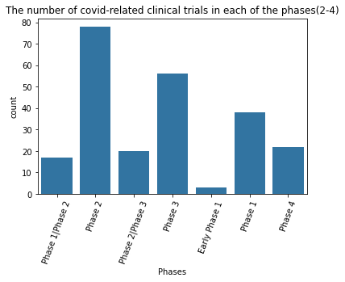

```python
base_color = sb.color_palette()[0]

sb.countplot(data=cct_phases, x='Phases', color=base_color)
plt.xticks(rotation=70)
plt.title('The number of covid-related clinical trials in each of the phases(2-4)');
```

```python
cct_phases['Study Type'].value_counts()
```

```
Interventional    234
Name: Study Type, dtype: int64
```

Interventional studies are also known as randomized controlled trials (RCTs), the gold standard in clinical research. In an RCT, particpants are randomly assigned to either the treatment group or the control group. The treatment group receives the drug being tested and the control group received the placebo or standard treatment. Then the results of the two groups are compared to determine the effectiveness of the intervention. Interventional studies help to make sure that the new treatments are safe and effective before they are released to the public.

### What are the top three sponsors?

```python
sponsor_counts = cct_phases['Sponsor/Collaborators'].value_counts()
```

```python
sponsor_counts_df = sponsor_counts.to_frame()
sponsor_counts_df
```

|  | Sponsor/Collaborators |
| --- | --- |
| National Institute of Allergy and Infectious Diseases (NIAID) | 4 |
| Novartis Pharmaceuticals\|Novartis | 3 |
| Gilead Sciences | 3 |
| Fundação de Medicina Tropical Dr. Heitor Vieira Dourado | 2 |
| Ridgeback Biotherapeutics, LP | 2 |
| Instituto Grifols, S.A.\|Grifols Therapeutics LLC | 2 |
| Burnasyan Federal Medical Biophysical Center | 2 |
| Emory University | 2 |
| Brii Biosciences Limited\|TSB Therapeutics (Beijing) CO.LTD | 2 |
| University of Chicago | 2 |
| St. Francis Hospital, New York | 2 |
| Stanford University | 2 |
| Hoffmann-La Roche | 2 |
| NYU Langone Health | 2 |
| World Medicine ILAC SAN. ve TIC. A.S.\|Novagenix Bioanalytical Drug R&D Center\|Farmagen Ar-Ge Biyot. Ltd. Sti | 2 |
| AstraZeneca\|Acerta Pharma B.V. | 2 |
| Hellenic Institute for the Study of Sepsis | 2 |
| FMH College of Medicine and Dentistry | 2 |
| Catalysis SL | 2 |
| Centenario Hospital Miguel Hidalgo | 2 |
| Gamaleya Research Institute of Epidemiology and Microbiology, Health Ministry of the Russian Federation\|Acellena Contract Drug Research and Development | 2 |
| Chronic Obstructive Pulmonary Disease Trial Network, Denmark | 1 |
| aTyr Pharma, Inc. | 1 |
| Sara Ghandehari\|IBSA Institut Biochimique SA\|Cedars-Sinai Medical Center | 1 |
| International Centre for Diarrhoeal Disease Research, Bangladesh | 1 |
| Eli Lilly and Company\|AbCellera Biologics Inc. | 1 |
| Hoffmann-La Roche\|Gilead Sciences | 1 |
| Genentech, Inc. | 1 |
| The Camelot Foundation | 1 |
| AO GENERIUM | 1 |

[output cut: 179 more lines]